# Language Sentiment Predicts Changes in Depression (Manuscript Results Analyses)

Jihyun Hur

## Results

- The scripts for all analyses in the results section are included below in the order reported in the paper.

Positive and negative human sentiment Spearman correlation

```r
## Study 1
cor.test(study1_data$avg_human_tone_pos_mean, study1_data$avg_human_tone_neg_mean, method="spearman")
```

```
##
##  Spearman's rank correlation rho
##
## data:  study1_data$avg_human_tone_pos_mean and study1_data$avg_human_tone_neg_mean
## S = 1816290, p-value < 2.2e-16
## alternative hypothesis: true rho is not equal to 0
## sample estimates:
##        rho
## -0.9001628
```

```r
## Study 2
cor.test(study2_data$avg_human_tone_pos_mean, study2_data$avg_human_tone_neg_mean, method="spearman")
```

```
##
##  Spearman's rank correlation rho
##
## data:  study2_data$avg_human_tone_pos_mean and study2_data$avg_human_tone_neg_mean
## S = 7630136, p-value < 2.2e-16
## alternative hypothesis: true rho is not equal to 0
## sample estimates:
##        rho
## -0.9165108
```

Human sentiment score ~ PHQ-9 at baseline

```r
## Study 1
cor.test(study1_data$phq, study1_data$avg_human_tone_mean_diff, method="spearman")
```

```
##
##  Spearman's rank correlation rho
##
## data:  study1_data$phq and study1_data$avg_human_tone_mean_diff
## S = 1590943, p-value < 2.2e-16
## alternative hypothesis: true rho is not equal to 0
## sample estimates:
##        rho
## -0.6644098
```

```r
## Study 2
cor.test(study2_data$phq, study2_data$avg_human_tone_mean_diff, method="spearman")
```

```
##
##  Spearman's rank correlation rho
##
## data:  study2_data$phq and study2_data$avg_human_tone_mean_diff
## S = 6279539, p-value < 2.2e-16
## alternative hypothesis: true rho is not equal to 0
## sample estimates:
##        rho
## -0.5772727
```

Human sentiment score ~ PHQ-9 at follow-up

```r
## Study 1
cor.test(study1_data$phq_2, study1_data$avg_human_tone_mean_diff, method="spearman")
```

```
##
##  Spearman's rank correlation rho
##
## data:  study1_data$phq_2 and study1_data$avg_human_tone_mean_diff
## S = 1539714, p-value < 2.2e-16
## alternative hypothesis: true rho is not equal to 0
## sample estimates:
##        rho
## -0.6108153
```

```r
## Study 2
cor.test(study2_data$phq_2, study2_data$avg_human_tone_mean_diff, method="spearman")
```

```
##
##  Spearman's rank correlation rho
##
## data:  study2_data$phq_2 and study2_data$avg_human_tone_mean_diff
## S = 6352987, p-value < 2.2e-16
## alternative hypothesis: true rho is not equal to 0
## sample estimates:
##        rho
## -0.5957212
```

PHQ-9 at baseline ~ PHQ-9 at follow-up

```r
## Study 1
cor.test(study1_data$phq, study1_data$phq_2, method="spearman")
```

```
##
##  Spearman's rank correlation rho
##
## data:  study1_data$phq and study1_data$phq_2
## S = 210187, p-value < 2.2e-16
## alternative hypothesis: true rho is not equal to 0
## sample estimates:
##       rho
## 0.7801074
```

```r
## Study 2
cor.test(study2_data$phq, study2_data$phq_2, method="spearman")
```

```
##
##  Spearman's rank correlation rho
##
## data:  study2_data$phq and study2_data$phq_2
## S = 651862, p-value < 2.2e-16
## alternative hypothesis: true rho is not equal to 0
## sample estimates:
##       rho
## 0.8362676
```

Robust regression testing human sentiment score

```r
# define variable full name for regression result table (tab_model below)
pi <- c(`(Intercept)` = "Intercept",
        phq = "Initial PHQ-9 score",
        avg_human_tone_mean_diff = "Human sentiment score",
        avg_human_tone_pos_mean = "Human positivity score",
        avg_human_tone_neg_mean = "Human negativity score",
        gpt_tone_mean_diff = "ChatGPT sentiment score",
        gpt_tone_pos_mean = "ChatGPT positivity score",
        gpt_tone_neg_mean = "ChatGPT negativity score",
        liwc_tone_mean_diff = "LIWC sentiment score",
        liwc_tone_pos_mean = "LIWC positivity score",
        liwc_tone_neg_mean = "LIWC negativity score",
        base_hap = "Baseline mood")

# define variables to inclde in regression result table (tab_model below)
terms_use <- c("phq", "avg_human_tone_mean_diff", "avg_human_tone_pos_mean", "avg_human_tone_neg_mean",
               "gpt_tone_mean_diff", "gpt_tone_pos_mean", "gpt_tone_neg_mean",
               "liwc_tone_mean_diff", "liwc_tone_pos_mean", "liwc_tone_neg_mean",
               "base_hap")

## Study 1
ms5_study1_mod <- lmrob(phq_2   ~   phq + age + gender + edu + avg_human_tone_mean_diff, data=study1_data,  control = lmrob.control(setting = "KS2014", k.max=2000))

tab_model(ms5_study1_mod,  terms = terms_use,
          show.ci = FALSE, show.se = TRUE,
             pred.labels = pi, dv.labels = c(""), string.pred = "Coeffcient",
            show.stat = TRUE, string.est = "Beta estimates", string.stat = "T-stat",
            string.se = "SE", string.p = "P")
```

| Coeffcient | Beta estimates | SE | T-stat | P |
| --- | --- | --- | --- | --- |
| Initial PHQ-9 score | 0.64 | 0.05 | 12.15 | **<0.001** |
| Human sentiment score | -0.26 | 0.09 | -3.11 | **0.002** |
| Observations | 178 |  |  |  |
| R<sup>2</sup> / R<sup>2</sup> adjusted | 0.739 / 0.717 |  |  |  |

```r
# f^2 calculation
# model without sentiment score
ms5_study1_mod2<-lmrob(phq_2   ~  phq  + age + gender + edu, data=study1_data,  control = lmrob.control(setting = "KS2014", k.max=2000))

s1_mod_f <- (summary(ms5_study1_mod)$r.squared - summary(ms5_study1_mod2)$r.squared)/(1-summary(ms5_study1_mod)$r.squared)
sprintf('Study 1 regression model Cohen f^2 = %.3f', s1_mod_f)
```

```
## [1] "Study 1 regression model Cohen f^2 = 0.051"
```

```r
## Study 2
ms5_study2_mod <- lmrob(phq_2   ~  phq + age + gender + edu + avg_human_tone_mean_diff, data=study2_data,  control = lmrob.control(setting = "KS2014", k.max=2000))

tab_model(ms5_study2_mod,  terms = terms_use,
          show.ci = FALSE, show.se = TRUE,
             pred.labels = pi, dv.labels = c(""), string.pred = "Coeffcient",
            show.stat = TRUE, string.est = "Beta estimates", string.stat = "T-stat",
            string.se = "SE", string.p = "P")
```

| Coeffcient | Beta estimates | SE | T-stat | P |
| --- | --- | --- | --- | --- |
| Initial PHQ-9 score | 0.85 | 0.04 | 21.35 | **<0.001** |
| Human sentiment score | -0.19 | 0.06 | -3.07 | **0.002** |
| Observations | 286 |  |  |  |
| R<sup>2</sup> / R<sup>2</sup> adjusted | 0.796 / 0.785 |  |  |  |

```r
# f^2 calculation
# model without sentiment score
ms5_study2_mod2<-lmrob(phq_2   ~  phq  + age + gender + edu, data=study2_data,  control = lmrob.control(setting = "KS2014", k.max=2000))

s2_mod_f <- (summary(ms5_study2_mod)$r.squared - summary(ms5_study2_mod2)$r.squared)/(1-summary(ms5_study2_mod)$r.squared)
sprintf('Study 2 regression model Cohen f^2 = %.3f', s2_mod_f)
```

```
## [1] "Study 2 regression model Cohen f^2 = 0.018"
```

Robust regression human sentiment plots (Fig. 1A)

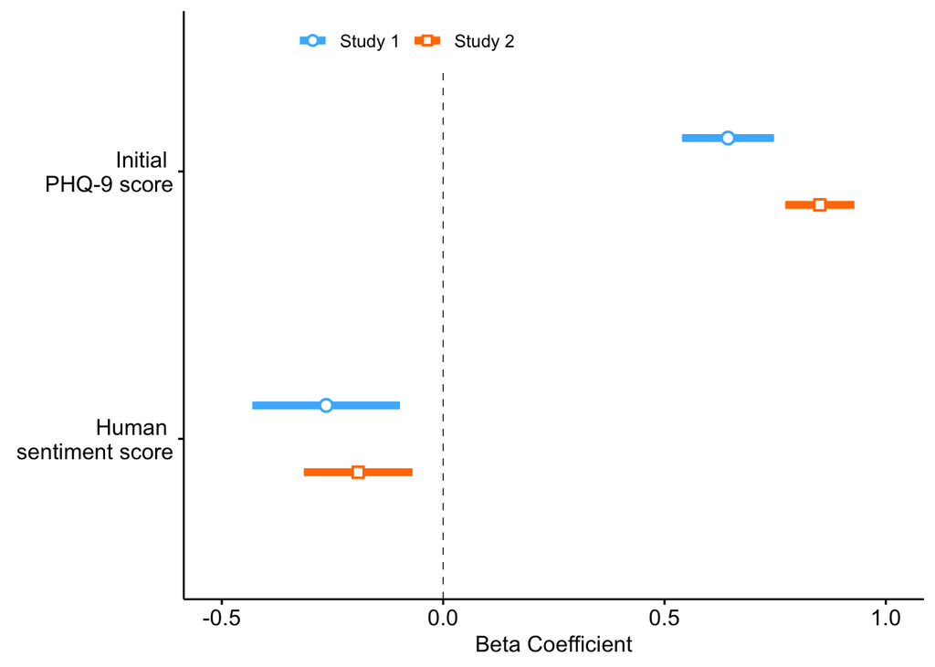

```r
reg_mod <- plot_summs(ms5_study1_mod, ms5_study2_mod, scale=FALSE, inner_ci_level = .95,  plot.distributions = FALSE,
                 rescale.distributions = TRUE,
                 coefs = c(
                   "Initial \nPHQ-9 score" = 'phq',
                   "Human \nsentiment score" = "avg_human_tone_mean_diff"),
                 model.names=c('Study 1', 'Study 2')) + scale_x_continuous(limits = c(-0.51, 1.01),
                                                                           breaks=c(-0.50, 0.00, 0.50, 1.00))
fig_1a <- ggpar(reg_mod, xlab = 'Beta Coefficient',
            font.y = 0,
            ggtheme = theme_pubr()) + theme(legend.title = element_blank(), legend.position = c(0.3,0.95),
                                            legend.direction = "horizontal")
# print Fig. 1A
fig_1a
```

[output not shown]

[output not shown]

[figure not shown]

LOOCV prediction (Study 1)

```r
## Study 1 LOOCV prediction
loocv_pred_values1 <- NULL

# Note: If only one participant in the category, the loocv model for that participant doesn't work
# exclude groups with only one participant
study1_data_loocv <- study1_data %>% filter(!is.nan(age) & edu !="No high school diploma" & gender != "Others")

for (i in 1:nrow(study1_data_loocv)) {
  loo_data <- study1_data_loocv[-i,]

  # sentiment model
  model1<-lmrob(phq_diff  ~ phq + avg_human_tone_mean_diff + age + gender + edu, data=loo_data,  control = lmrob.control(setting = "KS2014", k.max=2000))
  loocv_pred_values1[i]  <- predict(model1, newdata=study1_data_loocv[i,], type = "response")
}

study1_data_loocv$loocv_pred_values         <- loocv_pred_values1
```

LOOCV prediction (Study 2)

```r
## Study 2 LOOCV prediction
loocv_pred_values2 <- NULL

# Note: If only one participant in the category, the loocv model for that participant doesn't work
# exclude groups with only one participant
study2_data_loocv <- study2_data %>% filter(!is.nan(age) & edu != "Prefer not to say" & gender != "Prefer not to say")

for (i in 1:nrow(study2_data_loocv)) {
  loo_data <- study2_data_loocv[-i,]
  # sentiment model
  model1<-lmrob(phq_diff   ~ phq + avg_human_tone_mean_diff + age + gender + edu, data=loo_data,  control = lmrob.control(setting = "KS2014", k.max=2000))
  loocv_pred_values2[i] <- predict(model1, newdata=study2_data_loocv[i,], type = "response")
}

study2_data_loocv$loocv_pred_values         <- loocv_pred_values2
```

LOOCV results

```r
## Study 1
s1_mse <- mean((study1_data_loocv$phq_diff-study1_data_loocv$loocv_pred_values)^2, na.rm=TRUE)
sprintf("Study 1 LOOCV RMSE = %.2f", sqrt(s1_mse))
```

```
## [1] "Study 1 LOOCV RMSE = 3.05"
```

```r
s1_mae <- mean(abs(study1_data_loocv$phq_diff-study1_data_loocv$loocv_pred_values), na.rm=TRUE)
sprintf("Study 1 LOOCV MAE = %.2f", s1_mae)
```

```
## [1] "Study 1 LOOCV MAE = 2.17"
```

```r
s1_R <- cor.test(study1_data_loocv$phq_diff, study1_data_loocv$loocv_pred_values, method="pearson")
sprintf("Study 1 Pred ~ Actual R = %.2f (P = %.3f)", s1_R$estimate[[1]], s1_R$p.value)
```

```
## [1] "Study 1 Pred ~ Actual R = 0.43 (P = 0.000)"
```

```r
## Study 2
s2_mse <- mean((study2_data_loocv$phq_diff-study2_data_loocv$loocv_pred_values)^2, na.rm=TRUE)
sprintf("Study 2 LOOCV RMSE = %.2f", sqrt(s2_mse))
```

```
## [1] "Study 2 LOOCV RMSE = 3.23"
```

```r
s2_mae <- mean(abs(study2_data_loocv$phq_diff-study2_data_loocv$loocv_pred_values), na.rm=TRUE)
sprintf("Study 2 LOOCV MAE = %.2f", s2_mae)
```

```
## [1] "Study 2 LOOCV MAE = 2.26"
```

```r
s2_R <- cor.test(study2_data_loocv$phq_diff, study2_data_loocv$loocv_pred_values, method="pearson")
sprintf("Study 2 Pred ~ Actual R = %.2f (P = %.3f)", s2_R$estimate[[1]], s2_R$p.value)
```

```
## [1] "Study 2 Pred ~ Actual R = 0.17 (P = 0.004)"
```

Model comparison using Wald tests

```r
## Study 1
anova(ms5_study1_mod, ms5_study1_mod2, test='Wald')
```

```
## Robust Wald Test Table
##
## Model 1: phq_2 ~ phq + age + gender + edu + avg_human_tone_mean_diff
## Model 2: phq_2 ~ phq + age + gender + edu
## Largest model fitted by lmrob(), i.e. SMDM
##
##   pseudoDf Test.Stat Df Pr(>chisq)
## 1      163
## 2      164    9.6469  1   0.001897 **
## ---
## Signif. codes:  0 '***' 0.001 '**' 0.01 '*' 0.05 '.' 0.1 ' ' 1
```

```r
## Study 2
anova(ms5_study2_mod, ms5_study2_mod2, test='Wald')
```

```
## Robust Wald Test Table
##
## Model 1: phq_2 ~ phq + age + gender + edu + avg_human_tone_mean_diff
## Model 2: phq_2 ~ phq + age + gender + edu
## Largest model fitted by lmrob(), i.e. SMDM
##
##   pseudoDf Test.Stat Df Pr(>chisq)
## 1      270
## 2      271    9.4103  1   0.002158 **
## ---
## Signif. codes:  0 '***' 0.001 '**' 0.01 '*' 0.05 '.' 0.1 ' ' 1
```

Robust mixed effect models to minimal and mild-to-moderate depression groups

```r
# combine study1 and study2 data
dat <- rbind(study1_data, study2_data)

# mixed linear effect model for participants with minimal depression symptoms (PHQ-9 < 5)
low_phq_lmer <- rlmer(phq_2   ~  phq + age + gender + edu + avg_human_tone_mean_diff + (1 |study_num), data = dat %>% filter(phq<5))
```

```
## boundary (singular) fit: see help('isSingular')
```

```r
tab_model(low_phq_lmer, terms = terms_use, pred.labels = pi, dv.labels = c(""),
          show.ci = FALSE,  show.se = TRUE, show.stat = TRUE, string.est = "Beta estimates", string.stat = "T-stat",
          string.se = "SE", string.p = "P")
```

| Predictors | Beta estimates | SE | T-stat | P |
| --- | --- | --- | --- | --- |
| Initial PHQ-9 score | 0.72 | 0.09 | 8.46 | **<0.001** |
| Human sentiment score | -0.15 | 0.05 | -2.95 | **0.003** |
| Random Effects |  |  |  |  |
| σ<sup>2</sup> | 2.70 |  |  |  |
| τ<sub>00</sub> <sub>study_num</sub> | 0.00 |  |  |  |
| ICC | 0.00 |  |  |  |
| N <sub>study_num</sub> | 2 |  |  |  |
| Observations | 217 |  |  |  |
| Marginal R<sup>2</sup> / Conditional R<sup>2</sup> | 0.391 / 0.391 |  |  |  |

```r
# mixed linear effect model for participants with minimal depression symptoms (PHQ-9 >= 5)
high_phq_lmer <- rlmer(phq_2   ~  phq + age + gender + edu +  avg_human_tone_mean_diff + (1 |study_num), data = dat %>% filter(phq>=5))

tab_model(high_phq_lmer, terms = terms_use, pred.labels = pi, dv.labels = c(""),
          show.ci = FALSE, show.se = TRUE, show.stat = TRUE, string.est = "Beta estimates",
          string.stat = "T-stat", string.se = "SE", string.p = "P")
```

| Predictors | Beta estimates | SE | T-stat | P |
| --- | --- | --- | --- | --- |
| Initial PHQ-9 score | 0.74 | 0.06 | 12.80 | **<0.001** |
| Human sentiment score | -0.29 | 0.09 | -3.23 | **0.001** |
| Random Effects |  |  |  |  |
| σ<sup>2</sup> | 10.59 |  |  |  |
| τ<sub>00</sub> <sub>study_num</sub> | 0.56 |  |  |  |
| ICC | 0.05 |  |  |  |
| N <sub>study_num</sub> | 2 |  |  |  |
| Observations | 247 |  |  |  |
| Marginal R<sup>2</sup> / Conditional R<sup>2</sup> | 0.594 / 0.615 |  |  |  |

Linguistic distance ~ PHQ

```r
## Study 1
cor.test(study1_data$liwc_ling_dist, study1_data$phq, method="spearman")
```

```
##
##  Spearman's rank correlation rho
##
## data:  study1_data$liwc_ling_dist and study1_data$phq
## S = 1495228, p-value = 0.02842
## alternative hypothesis: true rho is not equal to 0
## sample estimates:
##        rho
## -0.1557776
```

```r
# Study 2
cor.test(study2_data$liwc_ling_dist, study2_data$phq, method="spearman")
```

```
##
##  Spearman's rank correlation rho
##
## data:  study2_data$liwc_ling_dist and study2_data$phq
## S = 6144038, p-value = 0.04028
## alternative hypothesis: true rho is not equal to 0
## sample estimates:
##        rho
## -0.1145363
```

Correlation between human and ChatGPT (GPT-3.5) sentiment

```r
## Study 1
cor.test(study1_data$avg_human_tone_mean_diff, study1_data$gpt_tone_mean_diff, method="spearman")
```

```
##
##  Spearman's rank correlation rho
##
## data:  study1_data$avg_human_tone_mean_diff and study1_data$gpt_tone_mean_diff
## S = 40741, p-value < 2.2e-16
## alternative hypothesis: true rho is not equal to 0
## sample estimates:
##       rho
## 0.9573778
```

```r
## Study 2
cor.test(study2_data$avg_human_tone_mean_diff, study2_data$gpt_tone_mean_diff, method="spearman")
```

```
##
##  Spearman's rank correlation rho
##
## data:  study2_data$avg_human_tone_mean_diff and study2_data$gpt_tone_mean_diff
## S = 177817, p-value < 2.2e-16
## alternative hypothesis: true rho is not equal to 0
## sample estimates:
##       rho
## 0.9553366
```

Correlation between PHQ-9 and ChatGPT (GPT-3.5) sentiment

```r
## Study 1
cor.test(study1_data$phq, study1_data$gpt_tone_mean_diff, method="spearman")
```

```
##
##  Spearman's rank correlation rho
##
## data:  study1_data$phq and study1_data$gpt_tone_mean_diff
## S = 1604180, p-value < 2.2e-16
## alternative hypothesis: true rho is not equal to 0
## sample estimates:
##        rho
## -0.6782581
```

```r
## Study 2
cor.test(study2_data$phq, study2_data$gpt_tone_mean_diff, method="spearman")
```

```
##
##  Spearman's rank correlation rho
##
## data:  study2_data$phq and study2_data$gpt_tone_mean_diff
## S = 6320053, p-value < 2.2e-16
## alternative hypothesis: true rho is not equal to 0
## sample estimates:
##        rho
## -0.5874489
```

Robust regression testing ChatGPT sentiment score

```r
## Study 1
ms10_study1_mod <- lmrob(phq_2   ~  phq + age + gender + edu +  gpt_tone_mean_diff, data=study1_data,  control = lmrob.control(setting = "KS2014", k.max=2000))

tab_model(ms10_study1_mod,  terms = terms_use,
          show.ci = FALSE, show.se = TRUE,
            pred.labels = pi, dv.labels = c(""), string.pred = "Coeffcient",
            show.stat = TRUE, string.est = "Beta estimates", string.stat = "T-stat",
            string.se = "SE", string.p = "P")
```

| Coeffcient | Beta estimates | SE | T-stat | P |
| --- | --- | --- | --- | --- |
| Initial PHQ-9 score | 0.67 | 0.05 | 12.56 | **<0.001** |
| ChatGPT sentiment score | -0.21 | 0.08 | -2.50 | **0.013** |
| Observations | 178 |  |  |  |
| R<sup>2</sup> / R<sup>2</sup> adjusted | 0.736 / 0.713 |  |  |  |

```r
# f^2 calculation
# model without sentiment score
ms10_study1_mod2<-lmrob(phq_2   ~  phq  + age + gender + edu, data=study1_data,  control = lmrob.control(setting = "KS2014", k.max=2000))
s1_mod_f <- (summary(ms10_study1_mod)$r.squared - summary(ms10_study1_mod2)$r.squared)/(1-summary(ms10_study1_mod)$r.squared)
sprintf('Study 1 regression model Cohen f^2 = %.3f', s1_mod_f)
```

```
## [1] "Study 1 regression model Cohen f^2 = 0.038"
```

```r
## Study 2
ms10_study2_mod <- lmrob(phq_2   ~  phq + age + gender + edu +  gpt_tone_mean_diff, data=study2_data,  control = lmrob.control(setting = "KS2014", k.max=2000))

tab_model(ms10_study2_mod,  terms = terms_use,
          show.ci = FALSE, show.se = TRUE,
             pred.labels = pi, dv.labels = c(""), string.pred = "Coeffcient",
            show.stat = TRUE, string.est = "Beta estimates", string.stat = "T-stat",
            string.se = "SE", string.p = "P")
```

| Coeffcient | Beta estimates | SE | T-stat | P |
| --- | --- | --- | --- | --- |
| Initial PHQ-9 score | 0.85 | 0.04 | 21.42 | **<0.001** |
| ChatGPT sentiment score | -0.18 | 0.06 | -2.99 | **0.003** |
| Observations | 286 |  |  |  |
| R<sup>2</sup> / R<sup>2</sup> adjusted | 0.796 / 0.785 |  |  |  |

```r
# f^2 calculation
# model without sentiment score
ms10_study2_mod2<-lmrob(phq_2   ~  phq  + age + gender + edu, data=study2_data,  control = lmrob.control(setting = "KS2014", k.max=2000))
s2_mod_f <- (summary(ms10_study2_mod)$r.squared - summary(ms10_study2_mod2)$r.squared)/(1-summary(ms10_study2_mod)$r.squared)
sprintf('Study 2 regression model Cohen f^2 = %.3f', s2_mod_f)
```

```
## [1] "Study 2 regression model Cohen f^2 = 0.018"
```

Robust regression ChatGPT sentiment score plot (Fig. 2A)

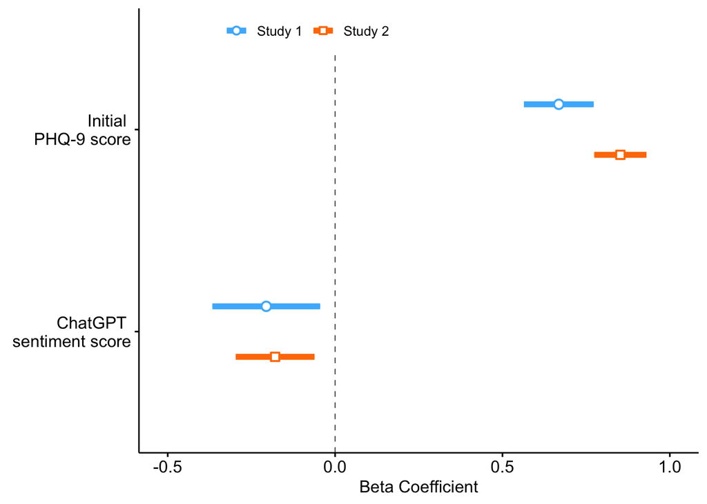

```r
gpt_reg_mod <- plot_summs(ms10_study1_mod, ms10_study2_mod, scale=FALSE, inner_ci_level = .95,  plot.distributions = FALSE,
                 rescale.distributions = TRUE,
                 coefs = c(
                   "Initial \nPHQ-9 score" = 'phq',
                   "ChatGPT \nsentiment score" = "gpt_tone_mean_diff"),
                 model.names=c('Study 1', 'Study 2')) + scale_x_continuous(limits = c(-0.51, 1.01),
                                                                           breaks=c(-0.50, 0.00, 0.50, 1.00))
fig_2a <- ggpar(gpt_reg_mod, xlab = 'Beta Coefficient',
            font.y = 0,
            ggtheme = theme_pubr()) + theme(legend.title = element_blank(), legend.position = c(0.3,0.95),
                                            legend.direction = "horizontal")
# print Fig. 2A
fig_2a
```

LIWC ~ Human sentiment score

```r
## Study 1
cor.test(study1_data$liwc_tone_mean_diff, study1_data$avg_human_tone_mean_diff, method="spearman")
```

```
##
##  Spearman's rank correlation rho
##
## data:  study1_data$liwc_tone_mean_diff and study1_data$avg_human_tone_mean_diff
## S = 240631, p-value < 2.2e-16
## alternative hypothesis: true rho is not equal to 0
## sample estimates:
##       rho
## 0.7482571
```

```r
## Study 2
cor.test(study2_data$liwc_tone_mean_diff, study2_data$avg_human_tone_mean_diff, method="spearman")
```

```
##
##  Spearman's rank correlation rho
##
## data:  study2_data$liwc_tone_mean_diff and study2_data$avg_human_tone_mean_diff
## S = 1153043, p-value < 2.2e-16
## alternative hypothesis: true rho is not equal to 0
## sample estimates:
##       rho
## 0.7103828
```

LIWC ~ GPT sentiment score

```r
## Study 1
cor.test(study1_data$liwc_tone_mean_diff, study1_data$gpt_tone_mean_diff, method="spearman")
```

```
##
##  Spearman's rank correlation rho
##
## data:  study1_data$liwc_tone_mean_diff and study1_data$gpt_tone_mean_diff
## S = 232755, p-value < 2.2e-16
## alternative hypothesis: true rho is not equal to 0
## sample estimates:
##       rho
## 0.7564972
```

```r
## Study 2
cor.test(study2_data$liwc_tone_mean_diff, study2_data$gpt_tone_mean_diff, method="spearman")
```

```
##
##  Spearman's rank correlation rho
##
## data:  study2_data$liwc_tone_mean_diff and study2_data$gpt_tone_mean_diff
## S = 1066514, p-value < 2.2e-16
## alternative hypothesis: true rho is not equal to 0
## sample estimates:
##       rho
## 0.7321168
```

LIWC ~ PHQ-9 at baseline

```r
## Study 1
cor.test(study1_data$liwc_tone_mean_diff, study1_data$phq, method="spearman")
```

```
##
##  Spearman's rank correlation rho
##
## data:  study1_data$liwc_tone_mean_diff and study1_data$phq
## S = 2001125, p-value = 2.095e-15
## alternative hypothesis: true rho is not equal to 0
## sample estimates:
##        rho
## -0.5236221
```

```r
## Study 2
cor.test(study2_data$liwc_tone_mean_diff, study2_data$phq, method="spearman")
```

```
##
##  Spearman's rank correlation rho
##
## data:  study2_data$liwc_tone_mean_diff and study2_data$phq
## S = 8102680, p-value < 2.2e-16
## alternative hypothesis: true rho is not equal to 0
## sample estimates:
##        rho
## -0.4698367
```

Robust regression testing LIWC sentiment score

```r
## Study 1
ms14_study1_mod <- lmrob(phq_2   ~  phq + age + gender + edu + liwc_tone_mean_diff, data=study1_data,
                         control = lmrob.control(setting = "KS2014", k.max=2000))

tab_model(ms14_study1_mod,  terms = terms_use,
          show.ci = FALSE, show.se = TRUE,
             pred.labels = pi, dv.labels = c(""), string.pred = "Coeffcient",
            show.stat = TRUE, string.est = "Beta estimates", string.stat = "T-stat",
            string.se = "SE", string.p = "P")
```

| Coeffcient | Beta estimates | SE | T-stat | P |
| --- | --- | --- | --- | --- |
| Initial PHQ-9 score | 0.76 | 0.05 | 16.84 | **<0.001** |
| LIWC sentiment score | 0.02 | 0.06 | 0.34 | 0.734 |
| Observations | 178 |  |  |  |
| R<sup>2</sup> / R<sup>2</sup> adjusted | 0.724 / 0.700 |  |  |  |

```r
# f^2 calculation
# model without sentiment score
ms14_study1_mod2<-lmrob(phq_2   ~  phq  + age + gender + edu, data=study1_data,  control = lmrob.control(setting = "KS2014", k.max=2000))
s1_mod_f <- (summary(ms14_study1_mod)$r.squared - summary(ms14_study1_mod2)$r.squared)/(1-summary(ms14_study1_mod)$r.squared)
sprintf('Study 1 regression model Cohen f^2 = %.3f', s1_mod_f)
```

```
## [1] "Study 1 regression model Cohen f^2 = -0.005"
```

```r
## Study 2
ms14_study2_mod <- lmrob(phq_2   ~  phq + age + gender + edu + liwc_tone_mean_diff, data=study2_data,
                         control = lmrob.control(setting = "KS2014", k.max=2000))

tab_model(ms14_study2_mod,  terms = terms_use,
          show.ci = FALSE, show.se = TRUE,
             pred.labels = pi, dv.labels = c(""), string.pred = "Coeffcient",
            show.stat = TRUE, string.est = "Beta estimates", string.stat = "T-stat",
            string.se = "SE", string.p = "P")
```

| Coeffcient | Beta estimates | SE | T-stat | P |
| --- | --- | --- | --- | --- |
| Initial PHQ-9 score | 0.91 | 0.04 | 25.75 | **<0.001** |
| LIWC sentiment score | -0.04 | 0.06 | -0.66 | 0.511 |
| Observations | 286 |  |  |  |
| R<sup>2</sup> / R<sup>2</sup> adjusted | 0.792 / 0.780 |  |  |  |

```r
# f^2 calculation
# model without sentiment score
ms14_study2_mod2<-lmrob(phq_2   ~  phq  + age + gender + edu, data=study2_data,  control = lmrob.control(setting = "KS2014", k.max=2000))
s2_mod_f <- (summary(ms14_study2_mod)$r.squared - summary(ms14_study2_mod2)$r.squared)/(1-summary(ms14_study2_mod)$r.squared)
sprintf('Study 2 regression model Cohen f^2 = %.3f', s2_mod_f)
```

```
## [1] "Study 2 regression model Cohen f^2 = -0.002"
```

Robust regression LIWC sentiment score plot (Fig. 2B)

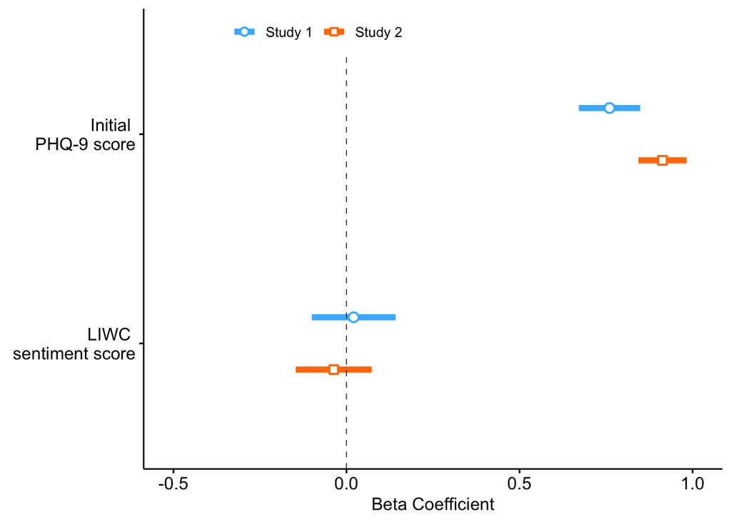

```r
liwc_reg_mod <- plot_summs(ms14_study1_mod, ms14_study2_mod, scale=FALSE, inner_ci_level = .95,  plot.distributions = FALSE,
                 rescale.distributions = TRUE,
                 coefs = c(
                   "Initial \nPHQ-9 score" = 'phq',
                   "LIWC \nsentiment score" = "liwc_tone_mean_diff"),
                 model.names=c('Study 1', 'Study 2')) + scale_x_continuous(limits = c(-0.51, 1.01),
                                                                           breaks=c(-0.50, 0.00, 0.50, 1.00))
fig_2b <- ggpar(liwc_reg_mod, xlab = 'Beta Coefficient',
            font.y = 0,
            ggtheme = theme_pubr()) + theme(legend.title = element_blank(), legend.position = c(0.3,0.95),
                                            legend.direction = "horizontal")
# print Fig. 2B
fig_2b
```

```r
# save Fig. 2B
fig_2 <- ggarrange(fig_2a, fig_2b, ncol = 2, nrow = 1, labels = c("A", "B"))
ggsave(filename = file.path(dir_save, "fig_2.pdf"), plot=fig_2, width=7, height=3.5, units="in", dpi=700)
```

Mean r2 of happiness modeling for each study & baseline mood parameter ~ human sentiment score

```r
## Study 1 mean r2
s1_mat_file <- "study1_riskytask_data.mat"
s1_task_dat <- readMat(file.path(dat_dir, s1_mat_file))

all_s1_r2 <- NULL

for (i in 1:length(s1_task_dat$datatosave)) {
  all_s1_r2[i] <- s1_task_dat$datatosave[[i]][[13]]
}
all_s1_r2[!is.finite(all_s1_r2)] <- NA
# include participants who completed the study
mean(all_s1_r2[!is.na(study1_data$phq_2)], na.rm=TRUE)
```

```
## [1] 0.5256317
```

```r
## Study 2 mean r2
s2_mat_file <- "study2_riskytask_data.mat"
s2_task_dat <- readMat(file.path(dat_dir, s2_mat_file))

all_s2_r2 <- NULL

for (i in 1:length(s2_task_dat$datatosave)) {
  all_s2_r2[i] <- s2_task_dat$datatosave[[i]][[13]]
}

all_s2_r2[!is.finite(all_s2_r2)] <- NA
# include participants who completed the study
mean(all_s2_r2[!is.na(study2_data$phq_2)], na.rm=TRUE)
```

```
## [1] 0.5472608
```

```r
## Study 1 cor: mood par ~ sentiment
cor.test(study1_data$base_hap, study1_data$avg_human_tone_mean_diff, method="spearman")
```

```
##
##  Spearman's rank correlation rho
##
## data:  study1_data$base_hap and study1_data$avg_human_tone_mean_diff
## S = 576616, p-value = 3.832e-08
## alternative hypothesis: true rho is not equal to 0
## sample estimates:
##       rho
## 0.3967569
```

```r
## Study 2 cor: mood par ~ sentiment
cor.test(study2_data$base_hap, study2_data$avg_human_tone_mean_diff, method="spearman")
```

```
##
##  Spearman's rank correlation rho
##
## data:  study2_data$base_hap and study2_data$avg_human_tone_mean_diff
## S = 2972499, p-value = 1.346e-05
## alternative hypothesis: true rho is not equal to 0
## sample estimates:
##       rho
## 0.2533781
```

RPE ~ human sentiment score

```r
## Study 1
cor.test(study1_data$rpe, study1_data$avg_human_tone_mean_diff, method="spearman")
```

```
##
##  Spearman's rank correlation rho
##
## data:  study1_data$rpe and study1_data$avg_human_tone_mean_diff
## S = 1029515, p-value = 0.3052
## alternative hypothesis: true rho is not equal to 0
## sample estimates:
##         rho
## -0.07705595
```

```r
## Study 2
cor.test(study2_data$rpe, study2_data$avg_human_tone_mean_diff, method="spearman")
```

```
##
##  Spearman's rank correlation rho
##
## data:  study2_data$rpe and study2_data$avg_human_tone_mean_diff
## S = 3997362, p-value = 0.9455
## alternative hypothesis: true rho is not equal to 0
## sample estimates:
##          rho
## -0.004043342
```

Risky task happiness plot (Fig. 3)

```r
# access the structure of Study 2 happiness data
main_struct <- s2_task_dat$datatosave
nrow <- dim(s2_task_dat$datatosave)[2]
df_list <- list()

# iterate through the rows
for (i in 1:nrow) {
  # Access the 1x1 struct for each row
  sub_struct <- main_struct[[i]]

  # Access and print the variables you need
  variable1 <- sub_struct[[1]] # rawhappy
  variable2 <- sub_struct[[12]] # Replace "variable2_name" with the actual variable name

  tmp_df <- data.frame(subjID = i, rawhappy = variable1, predhappy = variable2)
  df_list[[i]] <- tmp_df
}

s2_task_dat_long <- do.call(rbind, df_list) %>%
  gather(name, value, -subjID) %>% group_by(subjID, name) %>% mutate(data_point = row_number())

# choose example subject ID = 309
subj_id = 309

s2_task_dat$datatosave[[subj_id]][[13]]
```

```
##          [,1]
## [1,] 0.286438
```

```r
s2_r2 <- format(round(s2_task_dat$datatosave[[subj_id]][[13]], 2), nsmall = 2)

# PHQ-9 score of the example participant
study2_data$phq[subj_id]
```

```
## [1] 22
```

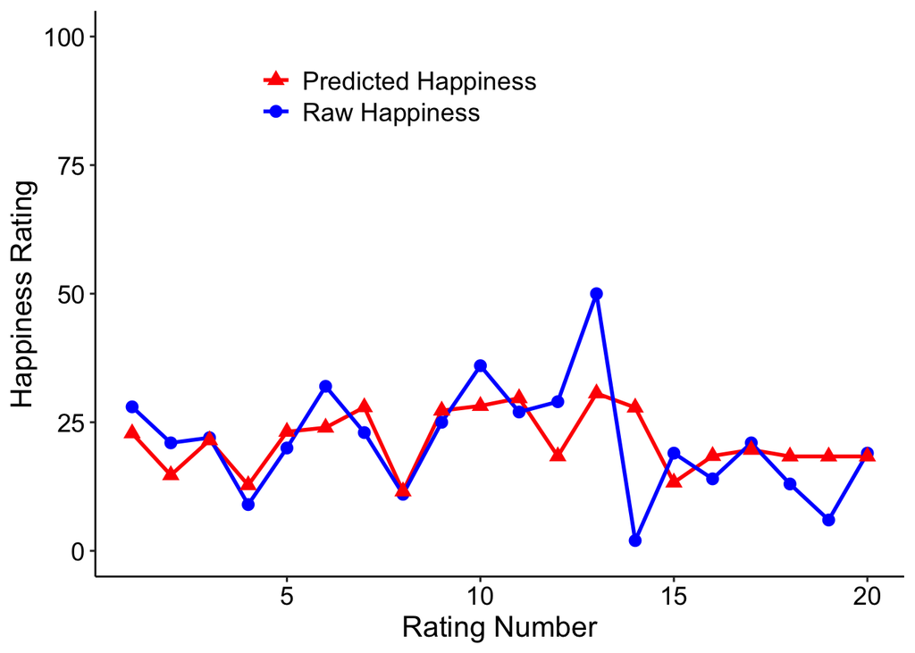

```r
fig_3a <- ggplot(s2_task_dat_long %>% filter(subjID == subj_id), aes(x = data_point, y=value, group=name, linetype=name, shape=name, colour=name)) +
  geom_line(size = 1) + ylim(c(0,100)) +
  geom_point(size = 3) + theme_pubr() + xlab('Rating Number') + ylab('Happiness Rating') +
  scale_linetype_manual(values = c("rawhappy" = "solid", "predhappy" = "solid"), labels = c("rawhappy" = "Raw Happiness", "predhappy" = "Predicted Happiness")) +
  scale_shape_manual( values = c("rawhappy" = 16, "predhappy" = 17), labels = c("rawhappy" = "Raw Happiness", "predhappy" = "Predicted Happiness")) +
  scale_color_manual(values = c("rawhappy" = "blue", "predhappy" = "red"), labels = c("rawhappy" = "Raw Happiness", "predhappy" = "Predicted Happiness")) + theme(legend.text=element_text(size=14), legend.position = c(0.375,0.85), legend.title = element_blank(),
        text = element_text(size = 14), axis.title = element_text(size = 16))

# print Fig. 3A
fig_3a
```

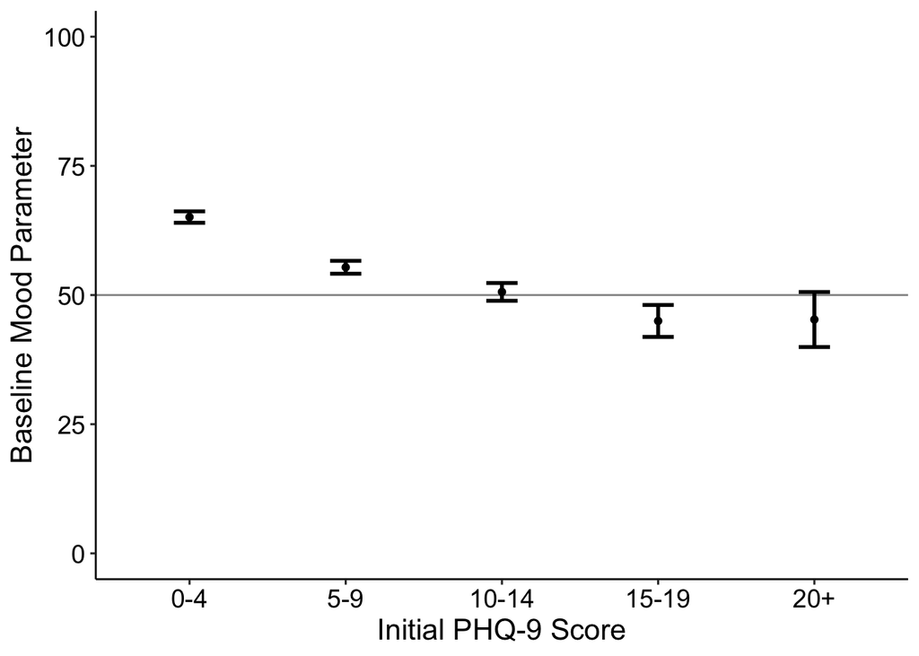

```r
# draw Fig 3b
# current mood (baseline happiness) by binned PHQ-9
fig_3b <- dat %>%
  group_by(Group = cut(phq, breaks = c(-Inf, 4, 9, 14, 19, +Inf),
                       labels = c("0-4", "5-9", "10-14","15-19", "20+"))) %>%
  summarise(mean_basehap = mean(base_hap), sem_basehap = sd(base_hap) / sqrt(n())) %>%

  # create the bar plot
  ggplot() +
  geom_point(aes(x = Group, y = mean_basehap, fill = Group), stat = "identity", size=1.5,
             position = position_dodge(width = 0.4), width = 1) + geom_hline(yintercept=50, alpha=0.5) +
  geom_errorbar(aes(x = Group, ymin = mean_basehap - sem_basehap, ymax = mean_basehap + sem_basehap), size = 1,
                position = position_dodge(width = 2), width = 0.2) +

  # customize plot aesthetics
  labs(x = "Initial PHQ-9 Score",
       y = "Baseline Mood Parameter") +
  theme_pubr() + ylim(c(0,100)) + theme(legend.position="none", text = element_text(size = 14), axis.title = element_text(size = 16))

# print Fig. 3B
fig_3b
```

```r
# save Fig. 3
fig_3 <- ggarrange(fig_3a, fig_3b, ncol=2, labels = c("A", "B"))
ggsave(filename = file.path(dir_save, "fig_3.pdf"), plot=fig_3, width=9, height=4, units="in", dpi=600)
```

Robust regression testing current depression using human sentiment score

```r
## Study 1
ms18_study1_mod <- lmrob(phq   ~ age + gender + edu + avg_human_tone_mean_diff + base_hap, data=study1_data,
                         control = lmrob.control(setting = "KS2014", k.max=2000))

tab_model(ms18_study1_mod,  terms = terms_use,
          show.ci = FALSE, show.se = TRUE,
             pred.labels = pi, dv.labels = c(""), string.pred = "Coeffcient",
            show.stat = TRUE, string.est = "Beta estimates", string.stat = "T-stat",
            string.se = "SE", string.p = "P")
```

| Coeffcient | Beta estimates | SE | T-stat | P |
| --- | --- | --- | --- | --- |
| Human sentiment score | -0.98 | 0.10 | -10.16 | **<0.001** |
| Baseline mood | -0.01 | 0.01 | -0.88 | 0.379 |
| Observations | 178 |  |  |  |
| R<sup>2</sup> / R<sup>2</sup> adjusted | 0.510 / 0.468 |  |  |  |

```r
# f^2 calculation
# model without sentiment score
ms18_study1_mod2<-lmrob(phq   ~  age + gender + edu + avg_human_tone_mean_diff,
                        data=study1_data,  control = lmrob.control(setting = "KS2014", k.max=2000))
s1_mod_f <- (summary(ms18_study1_mod)$r.squared - summary(ms18_study1_mod2)$r.squared)/(1-summary(ms18_study1_mod)$r.squared)
sprintf('Study 1 regression model Cohen f^2 = %.3f', s1_mod_f)
```

```
## [1] "Study 1 regression model Cohen f^2 = 0.001"
```

```r
## Study 2
ms18_study2_mod <- lmrob(phq   ~ age + gender + edu + avg_human_tone_mean_diff + base_hap,
                         data=study2_data,
                         control = lmrob.control(setting = "KS2014", k.max=2000))

tab_model(ms18_study2_mod,  terms = terms_use,
          show.ci = FALSE, show.se = TRUE,
             pred.labels = pi, dv.labels = c(""), string.pred = "Coeffcient",
            show.stat = TRUE, string.est = "Beta estimates", string.stat = "T-stat",
            string.se = "SE", string.p = "P")
```

| Coeffcient | Beta estimates | SE | T-stat | P |
| --- | --- | --- | --- | --- |
| Human sentiment score | -0.82 | 0.08 | -9.96 | **<0.001** |
| Baseline mood | -0.04 | 0.01 | -2.90 | **0.004** |
| Observations | 286 |  |  |  |
| R<sup>2</sup> / R<sup>2</sup> adjusted | 0.459 / 0.429 |  |  |  |

```r
# f^2 calculation
# model without sentiment score
ms18_study2_mod2<-lmrob(phq   ~  age + gender + edu + avg_human_tone_mean_diff, data=study2_data,  control = lmrob.control(setting = "KS2014", k.max=2000))
s2_mod_f <- (summary(ms18_study2_mod)$r.squared - summary(ms18_study2_mod2)$r.squared)/(1-summary(ms18_study2_mod)$r.squared)
sprintf('Study 2 regression model Cohen f^2 = %.3f', s2_mod_f)
```

```
## [1] "Study 2 regression model Cohen f^2 = 0.026"
```

Robust regression testing baseline mood parameter

```r
## Study 1
ms19_study1_mod <- lmrob(phq_2   ~ phq + age + gender + edu + base_hap, data=study1_data,
                         control = lmrob.control(setting = "KS2014", k.max=2000))

tab_model(ms19_study1_mod,  terms = terms_use,
          show.ci = FALSE, show.se = TRUE,
             pred.labels = pi, dv.labels = c(""), string.pred = "Coeffcient",
            show.stat = TRUE, string.est = "Beta estimates", string.stat = "T-stat",
            string.se = "SE", string.p = "P")
```

| Coeffcient | Beta estimates | SE | T-stat | P |
| --- | --- | --- | --- | --- |
| Initial PHQ-9 score | 0.74 | 0.04 | 17.33 | **<0.001** |
| Baseline mood | -0.01 | 0.01 | -0.94 | 0.346 |
| Observations | 178 |  |  |  |
| R<sup>2</sup> / R<sup>2</sup> adjusted | 0.726 / 0.703 |  |  |  |

```r
# f^2 calculation
# model without baseline mood par
ms19_study1_mod2<-lmrob(phq_2  ~ phq + age + gender + edu,
                        data=study1_data,  control = lmrob.control(setting = "KS2014", k.max=2000))
s1_mod_f <- (summary(ms19_study1_mod)$r.squared - summary(ms19_study1_mod2)$r.squared)/(1-summary(ms19_study1_mod)$r.squared)
sprintf('Study 1 regression model Cohen f^2 = %.3f', s1_mod_f)
```

```
## [1] "Study 1 regression model Cohen f^2 = 0.003"
```

```r
## Study 2
ms19_study2_mod <- lmrob(phq_2   ~ phq + age + gender + edu + base_hap,
                         data=study2_data,
                         control = lmrob.control(setting = "KS2014", k.max=2000))

tab_model(ms19_study2_mod,  terms = terms_use,
          show.ci = FALSE, show.se = TRUE,
             pred.labels = pi, dv.labels = c(""), string.pred = "Coeffcient",
            show.stat = TRUE, string.est = "Beta estimates", string.stat = "T-stat",
            string.se = "SE", string.p = "P")
```

| Coeffcient | Beta estimates | SE | T-stat | P |
| --- | --- | --- | --- | --- |
| Initial PHQ-9 score | 0.91 | 0.03 | 26.90 | **<0.001** |
| Baseline mood | -0.01 | 0.01 | -1.11 | 0.267 |
| Observations | 286 |  |  |  |
| R<sup>2</sup> / R<sup>2</sup> adjusted | 0.792 / 0.781 |  |  |  |

```r
# f^2 calculation
# model without baseline mood par
ms19_study2_mod2<-lmrob(phq_2   ~phq + age + gender + edu, data=study2_data,  control = lmrob.control(setting = "KS2014", k.max=2000))
s2_mod_f <- (summary(ms19_study2_mod)$r.squared - summary(ms19_study2_mod2)$r.squared)/(1-summary(ms19_study2_mod)$r.squared)
sprintf('Study 2 regression model Cohen f^2 = %.5f', s2_mod_f)
```

```
## [1] "Study 2 regression model Cohen f^2 = 0.00041"
```

Robust regression testing human sentiment score beyond baseline mood

```r
## Study 1
ms20_study1_mod <- lmrob(phq_2   ~ phq + age + gender + edu + base_hap + avg_human_tone_mean_diff, data=study1_data,
                         control = lmrob.control(setting = "KS2014", k.max=2000))

tab_model(ms20_study1_mod,  terms = terms_use,
          show.ci = FALSE, show.se = TRUE,
             pred.labels = pi, dv.labels = c(""), string.pred = "Coeffcient",
            show.stat = TRUE, string.est = "Beta estimates", string.stat = "T-stat",
            string.se = "SE", string.p = "P")
```

| Coeffcient | Beta estimates | SE | T-stat | P |
| --- | --- | --- | --- | --- |
| Initial PHQ-9 score | 0.64 | 0.05 | 12.05 | **<0.001** |
| Baseline mood | -0.00 | 0.01 | -0.11 | 0.912 |
| Human sentiment score | -0.26 | 0.09 | -2.95 | **0.004** |
| Observations | 178 |  |  |  |
| R<sup>2</sup> / R<sup>2</sup> adjusted | 0.738 / 0.714 |  |  |  |

```r
# f^2 calculation
# model without sentiment score
ms20_study1_mod2<-lmrob(phq_2  ~ phq + age + gender + edu + base_hap,
                        data=study1_data,  control = lmrob.control(setting = "KS2014", k.max=2000))
s1_mod_f <- (summary(ms20_study1_mod)$r.squared - summary(ms20_study1_mod2)$r.squared)/(1-summary(ms20_study1_mod)$r.squared)
sprintf('Study 1 regression model Cohen f^2 = %.3f', s1_mod_f)
```

```
## [1] "Study 1 regression model Cohen f^2 = 0.045"
```

```r
## Study 2
ms20_study2_mod <- lmrob(phq_2   ~ phq + age + gender + edu + base_hap + avg_human_tone_mean_diff,
                         data=study2_data,
                         control = lmrob.control(setting = "KS2014", k.max=2000))

tab_model(ms20_study2_mod,  terms = terms_use,
          show.ci = FALSE, show.se = TRUE,
             pred.labels = pi, dv.labels = c(""), string.pred = "Coeffcient",
            show.stat = TRUE, string.est = "Beta estimates", string.stat = "T-stat",
            string.se = "SE", string.p = "P")
```

| Coeffcient | Beta estimates | SE | T-stat | P |
| --- | --- | --- | --- | --- |
| Initial PHQ-9 score | 0.85 | 0.04 | 20.86 | **<0.001** |
| Baseline mood | -0.01 | 0.01 | -0.54 | 0.590 |
| Human sentiment score | -0.19 | 0.06 | -2.91 | **0.004** |
| Observations | 286 |  |  |  |
| R<sup>2</sup> / R<sup>2</sup> adjusted | 0.796 / 0.783 |  |  |  |

```r
# f^2 calculation
# model without sentiment score
ms20_study2_mod2<-lmrob(phq_2   ~ phq + age + gender + edu + base_hap, data=study2_data,  control = lmrob.control(setting = "KS2014", k.max=2000))
s2_mod_f <- (summary(ms20_study2_mod)$r.squared - summary(ms20_study2_mod2)$r.squared)/(1-summary(ms20_study2_mod)$r.squared)
sprintf('Study 2 regression model Cohen f^2 = %.3f', s2_mod_f)
```

```
## [1] "Study 2 regression model Cohen f^2 = 0.017"
```

Robust regression testing GPT sentiment score beyond baseline mood

```r
## Study 1
ms21_study1_mod <- lmrob(phq_2   ~ phq + age + gender + edu + base_hap + gpt_tone_mean_diff, data=study1_data,
                         control = lmrob.control(setting = "KS2014", k.max=2000))

tab_model(ms21_study1_mod,  terms = terms_use,
          show.ci = FALSE, show.se = TRUE,
             pred.labels = pi, dv.labels = c(""), string.pred = "Coeffcient",
            show.stat = TRUE, string.est = "Beta estimates", string.stat = "T-stat",
            string.se = "SE", string.p = "P")
```

| Coeffcient | Beta estimates | SE | T-stat | P |
| --- | --- | --- | --- | --- |
| Initial PHQ-9 score | 0.67 | 0.05 | 12.42 | **<0.001** |
| Baseline mood | -0.00 | 0.01 | -0.34 | 0.732 |
| ChatGPT sentiment score | -0.20 | 0.09 | -2.33 | **0.021** |
| Observations | 178 |  |  |  |
| R<sup>2</sup> / R<sup>2</sup> adjusted | 0.735 / 0.711 |  |  |  |

```r
# f^2 calculation
# model without sentiment score
ms21_study1_mod2<-lmrob(phq_2  ~ phq + age + gender + edu + base_hap,
                        data=study1_data,  control = lmrob.control(setting = "KS2014", k.max=2000))
s1_mod_f <- (summary(ms21_study1_mod)$r.squared - summary(ms21_study1_mod2)$r.squared)/(1-summary(ms21_study1_mod)$r.squared)
sprintf('Study 1 regression model Cohen f^2 = %.3f', s1_mod_f)
```

```
## [1] "Study 1 regression model Cohen f^2 = 0.033"
```

```r
## Study 2
ms21_study2_mod <- lmrob(phq_2   ~ phq + age + gender + edu + base_hap + gpt_tone_mean_diff,
                         data=study2_data,
                         control = lmrob.control(setting = "KS2014", k.max=2000))

tab_model(ms21_study2_mod,  terms = terms_use,
          show.ci = FALSE, show.se = TRUE,
             pred.labels = pi, dv.labels = c(""), string.pred = "Coeffcient",
            show.stat = TRUE, string.est = "Beta estimates", string.stat = "T-stat",
            string.se = "SE", string.p = "P")
```

| Coeffcient | Beta estimates | SE | T-stat | P |
| --- | --- | --- | --- | --- |
| Initial PHQ-9 score | 0.85 | 0.04 | 20.98 | **<0.001** |
| Baseline mood | -0.00 | 0.01 | -0.52 | 0.604 |
| ChatGPT sentiment score | -0.17 | 0.06 | -2.82 | **0.005** |
| Observations | 286 |  |  |  |
| R<sup>2</sup> / R<sup>2</sup> adjusted | 0.796 / 0.783 |  |  |  |

```r
# f^2 calculation
# model without sentiment score
ms21_study2_mod2<-lmrob(phq_2   ~ phq + age + gender + edu + base_hap, data=study2_data,  control = lmrob.control(setting = "KS2014", k.max=2000))
s2_mod_f <- (summary(ms21_study2_mod)$r.squared - summary(ms21_study2_mod2)$r.squared)/(1-summary(ms21_study2_mod)$r.squared)
sprintf('Study 2 regression model Cohen f^2 = %.3f', s2_mod_f)
```

```
## [1] "Study 2 regression model Cohen f^2 = 0.017"
```

Robust regression testing LIWC sentiment score beyond baseline mood

```r
## Study 1
ms22_study1_mod <- lmrob(phq_2   ~ phq + age + gender + edu + base_hap + liwc_tone_mean_diff, data=study1_data,
                         control = lmrob.control(setting = "KS2014", k.max=2000))

tab_model(ms22_study1_mod,  terms = terms_use,
          show.ci = FALSE, show.se = TRUE,
             pred.labels = pi, dv.labels = c(""), string.pred = "Coeffcient",
            show.stat = TRUE, string.est = "Beta estimates", string.stat = "T-stat",
            string.se = "SE", string.p = "P")
```

| Coeffcient | Beta estimates | SE | T-stat | P |
| --- | --- | --- | --- | --- |
| Initial PHQ-9 score | 0.75 | 0.05 | 16.14 | **<0.001** |
| Baseline mood | -0.01 | 0.01 | -1.04 | 0.301 |
| LIWC sentiment score | 0.04 | 0.06 | 0.64 | 0.523 |
| Observations | 178 |  |  |  |
| R<sup>2</sup> / R<sup>2</sup> adjusted | 0.724 / 0.698 |  |  |  |

```r
# f^2 calculation
# model without sentiment score
ms22_study1_mod2<-lmrob(phq_2  ~ phq + age + gender + edu + base_hap,
                        data=study1_data,  control = lmrob.control(setting = "KS2014", k.max=2000))
s1_mod_f <- (summary(ms22_study1_mod)$r.squared - summary(ms22_study1_mod2)$r.squared)/(1-summary(ms22_study1_mod)$r.squared)
sprintf('Study 1 regression model Cohen f^2 = %.3f', s1_mod_f)
```

```
## [1] "Study 1 regression model Cohen f^2 = -0.010"
```

```r
## Study 2
ms22_study2_mod <- lmrob(phq_2   ~ phq + age + gender + edu + base_hap + liwc_tone_mean_diff,
                         data=study2_data,
                         control = lmrob.control(setting = "KS2014", k.max=2000))

tab_model(ms22_study2_mod,  terms = terms_use,
          show.ci = FALSE, show.se = TRUE,
             pred.labels = pi, dv.labels = c(""), string.pred = "Coeffcient",
            show.stat = TRUE, string.est = "Beta estimates", string.stat = "T-stat",
            string.se = "SE", string.p = "P")
```

| Coeffcient | Beta estimates | SE | T-stat | P |
| --- | --- | --- | --- | --- |
| Initial PHQ-9 score | 0.90 | 0.04 | 24.76 | **<0.001** |
| Baseline mood | -0.01 | 0.01 | -1.01 | 0.315 |
| LIWC sentiment score | -0.03 | 0.06 | -0.48 | 0.629 |
| Observations | 286 |  |  |  |
| R<sup>2</sup> / R<sup>2</sup> adjusted | 0.792 / 0.779 |  |  |  |

```r
# f^2 calculation
# model without sentiment score
ms22_study2_mod2<-lmrob(phq_2   ~ phq + age + gender + edu + base_hap, data=study2_data,  control = lmrob.control(setting = "KS2014", k.max=2000))
s2_mod_f <- (summary(ms22_study2_mod)$r.squared - summary(ms22_study2_mod2)$r.squared)/(1-summary(ms22_study2_mod)$r.squared)
sprintf('Study 2 regression model Cohen f^2 = %.3f', s2_mod_f)
```

```
## [1] "Study 2 regression model Cohen f^2 = -0.002"
```